# World Health Organization Cholesterol Data vs. Cardiovascular Death Rates

Steve Bargelt

August 31, 2016

### Load packages

```r
library(WHO)
library(plyr)
library(dplyr)
library(ggplot2)
library(scales)
library(showtext)
library(scatterD3)
library(stringr)
library(RColorBrewer)
library(dygraphs)
```

## Background and Inspiration

I watched a presentataion by Zoë Harcombe and where she referenced her data analysis of World Health Organization data on cholesterol and cardiovascular disease mortality rates. She mentioned that the relationshio between cholesterol numbers and cardiovascular related deaths is the opposite of what you’d expect. I found her original post on the subject [Zoë Harcombe’s cholesterol and heart disease relationship](http://www.zoeharcombe.com/2010/11/cholesterol-heart-disease-there-is-a-relationship-but-its-not-what-you-think/)

I was pretty surprised that she did not publish how she came to this conculsion. In other words, the results were not reproducable. I wanted to reproduce this result and share all of the data **and code** so that other’s can critique my methods and results. Here is my repo with all code and data acquisition code so others can investigate my work [Github](https://github.com/stevebargelt/WHO-Data).

### Sources and More Information

You can find all of the source code at [Github](https://github.com/stevebargelt/WHO-Data)

[World Health Organization (WHO) Global Health Observatory (GHO)](http://www.who.int/gho/en/)

[WHO Cholesterol Data](http://apps.who.int/gho/data/node.main.A883?lang=en)

[WHO Ischaemic Data](https://rho.emro.who.int/rhodata/node.main.A1079?lang=en)

[WHO Cerebrovascular Data](https://rho.emro.who.int/rhodata/node.main.A1073?lang=en)

## Data Acquisition

The data takes quite a while to download from the WHO (3-4 minutes on a fast internet connection). You will find a stand-alone R script in the Github repo that will save the data to local files to speed up ad-hoc analysis.

### Use the WHO API to get the data we want to analyze.

```r
CHO_Age_Stand <- get_data("CHOL_03")
CHO_Crude <- get_data("CHOL_04")
#CVD_Cerebrovascular_DALY <- get_data("SA_0000001689")
CVD_Cerebrovascular <- get_data("SA_0000001690")
#CVD_Ischaemic_DALY <- get_data("SA_0000001425")
CVD_Ischaemic <- get_data("SA_0000001444")
```

## Tidying up the data

The Cholesterol (CHO) values are stored in the as a character string “5.0 [4.8-5.3]” - the following code strips out everything between and including the [ ] leaving us with a numeric value for each entry.

```r
CHO_Age_Stand$value <- gsub( " *\\[.*?\\] *", "", CHO_Age_Stand$value)
CHO_Age_Stand$value <- as.numeric(CHO_Age_Stand$value)
CHO_Crude$value <- gsub( " *\\[.*?\\] *", "", CHO_Crude$value)
CHO_Crude$value <- as.numeric(CHO_Crude$value)
```

Combine [Cerebrovascular](https://en.wikipedia.org/wiki/Cerebrovascular_disease) (strokes) and [Ischaemic](https://en.wikipedia.org/wiki/Coronary_artery_disease) (heart attack) death rates to get a picture of all Cardiovascualr death rates.

```r
CVD_ALL <- merge(CVD_Cerebrovascular, CVD_Ischaemic, by=c("year", "region", "country", "sex", "publishstate"))
CVD_ALL$totalCVDvalue = CVD_ALL$value.x + CVD_ALL$value.y
colnames(CVD_ALL)[7] <- "cerrbrovascularValue"
colnames(CVD_ALL)[9] <- "ischaemicValue"
CVD_ALL$gho.y <- NULL
CVD_ALL$gho.x <- NULL
```

Merge cholesterol data with all cardiovascular death data

```r
db <- merge(CVD_ALL, CHO_Crude, by=c("year", "region", "country", "sex", "publishstate"))
colnames(db)[11] <- "choCrudeValue"
db$gho <- NULL

choDeathData <- merge(db, CHO_Age_Stand, by=c("year", "region", "country", "sex", "publishstate", "agegroup"))
colnames(choDeathData)[12] <- "choAgeStandValue"
choDeathData$gho <- NULL
choDeathData$publishstate <- NULL
choDeathData$agegroup <- NULL
choDeathData$sex <- as.factor((choDeathData$sex))
```

### Age Standardized vs. Crude Cholesterol Numbers

Must decide on one or the other since not all values are present for all data points.

Mean Age Standardized: 4.7318182  
Mean Crude: 4.7073034  
Median Age Standardized: 4.7  
Median Crude: 4.7  
IQR Age Standardized: 0.7  
IQR Crude: 0.8  
Number of complete samples Crude: 356  
Number of complete samples Age Standardized: 374

I have decided to use Age Standardized value since there are ~20 more complete cases.

```r
#choDeathData$choCrudeValue <- NULL
choDeathData <- choDeathData[complete.cases(choDeathData[,c(7,8)]),]
```

## Analysis

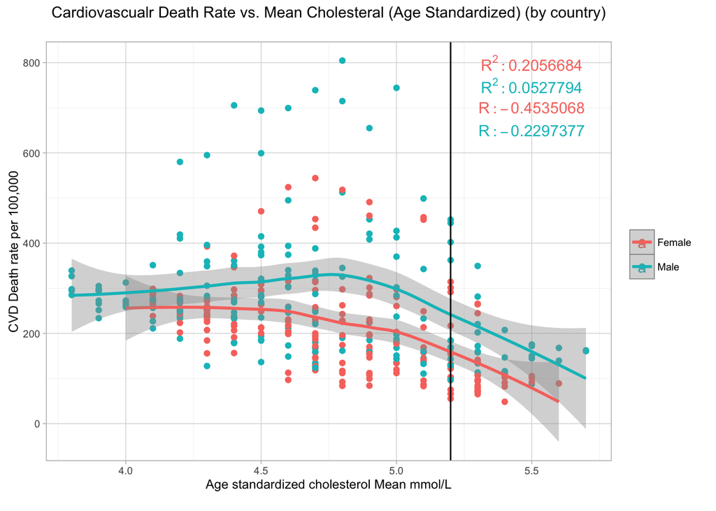

This chart is interactive. You can zoom in and out on the data points. You can also hover over the Legend on the right to highlight only the data that corresponds to the symbol or color you are hovering over. Hovering over a datapoint gives your more information. Finally you can lasso (SHIFT-Click and Drag) a set of points to single them out.

[interactive chart not shown]

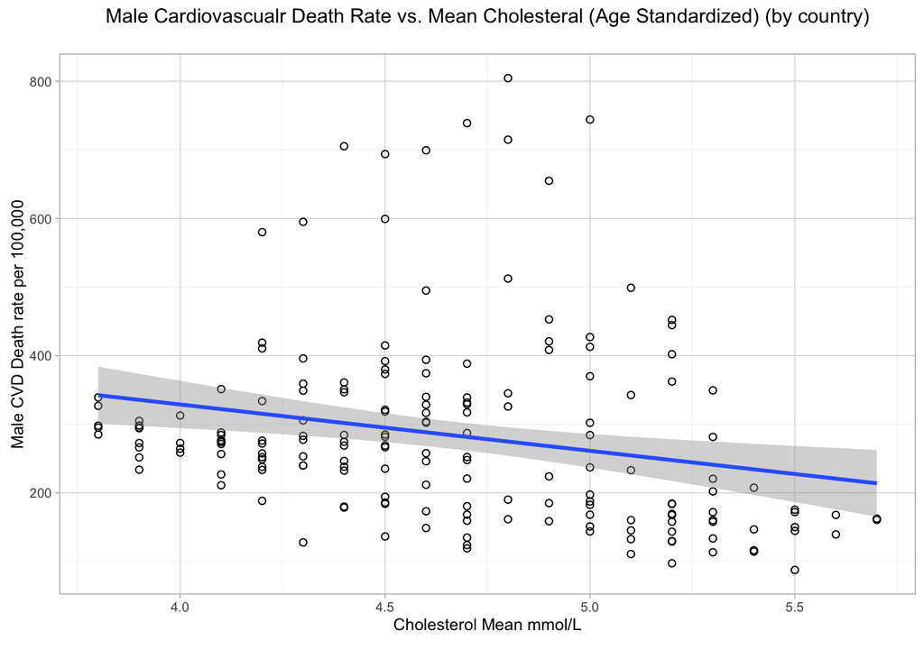

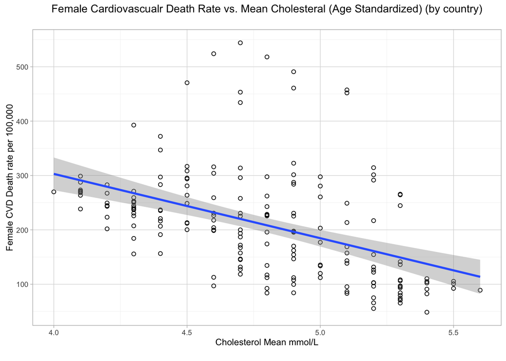

## Conclusion

It seems from the data that there is no correlation between high cholesterol and cadiovascular disease deaths. As a matter of fact the opposite seems to be true; countries with higher cholesterol levels have lower CVD death rates than countries with lower cholesterol levels.